# 0. Preparing

## Format the cell output

```python
from IPython.core.display import HTML

HTML(
    """<style>div.output_area pre{white-space: pre;}</style>
    <script>
code_show_err=false;
function code_toggle_err() {
 if (code_show_err){
 $('div.output_stderr').hide();
 } else {
 $('div.output_stderr').show();
 }
 code_show_err = !code_show_err
}
$( document ).ready(code_toggle_err);
</script>
To toggle on/off output_stderr, click <a href="javascript:code_toggle_err()">here</a>."""
)
```

To toggle on/off output_stderr, click here.

## Create Spark Session on top of YARN

```python
import pyspark

spark = (
    pyspark.sql.SparkSession.builder.appName("RegressionAnalysis")
    .master("yarn")
    .config("spark.executor.memory", "512m")
    .config("spark.executor.instances", "2")
    .getOrCreate()
)
spark
```

```
Setting default log level to "WARN".
To adjust logging level use sc.setLogLevel(newLevel). For SparkR, use setLogLevel(newLevel).
```

```
23/02/15 00:23:51 WARN NativeCodeLoader: Unable to load native-hadoop library for your platform... using builtin-java classes where applicable
23/02/15 00:23:52 WARN Client: Neither spark.yarn.jars nor spark.yarn.archive is set, falling back to uploading libraries under SPARK_HOME.
```

**SparkSession - in-memory**

**SparkContext**

[Spark UI](http://node-master:4040)

**Version**

`v3.3.1`

**Master**

`yarn`

**AppName**

`RegressionAnalysis`

## Load data from hdfs

```python
df = spark.read.option("header", "true").csv(
    "hdfs://node-master:9000/user/hadoop/KAG_conversion_data.csv", inferSchema=True
)
```

## Quick look at the data

```python
df.printSchema()
df.show()
df.count()
```

```
root
 |-- ad_id: integer (nullable = true)
 |-- xyz_campaign_id: integer (nullable = true)
 |-- fb_campaign_id: integer (nullable = true)
 |-- age: string (nullable = true)
 |-- gender: string (nullable = true)
 |-- interest: integer (nullable = true)
 |-- Impressions: integer (nullable = true)
 |-- Clicks: integer (nullable = true)
 |-- Spent: double (nullable = true)
 |-- Total_Conversion: integer (nullable = true)
 |-- Approved_Conversion: integer (nullable = true)

+------+---------------+--------------+-----+------+--------+-----------+------+-----------+----------------+-------------------+
| ad_id|xyz_campaign_id|fb_campaign_id|  age|gender|interest|Impressions|Clicks|      Spent|Total_Conversion|Approved_Conversion|
+------+---------------+--------------+-----+------+--------+-----------+------+-----------+----------------+-------------------+
|708746|            916|        103916|30-34|     M|      15|       7350|     1|1.429999948|               2|                  1|
|708749|            916|        103917|30-34|     M|      16|      17861|     2|1.820000023|               2|                  0|
|708771|            916|        103920|30-34|     M|      20|        693|     0|        0.0|               1|                  0|
|708815|            916|        103928|30-34|     M|      28|       4259|     1|       1.25|               1|                  0|
|708818|            916|        103928|30-34|     M|      28|       4133|     1|1.289999962|               1|                  1|
|708820|            916|        103929|30-34|     M|      29|       1915|     0|        0.0|               1|                  1|
|708889|            916|        103940|30-34|     M|      15|      15615|     3|4.769999981|               1|                  0|
|708895|            916|        103941|30-34|     M|      16|      10951|     1|1.269999981|               1|                  1|
|708953|            916|        103951|30-34|     M|      27|       2355|     1|        1.5|               1|                  0|
|708958|            916|        103952|30-34|     M|      28|       9502|     3|3.159999967|               1|                  0|
|708979|            916|        103955|30-34|     M|      31|       1224|     0|        0.0|               1|                  0|
|709023|            916|        103962|30-34|     M|       7|        735|     0|        0.0|               1|                  0|
|709038|            916|        103965|30-34|     M|      16|       5117|     0|        0.0|               1|                  0|
|709040|            916|        103965|30-34|     M|      16|       5120|     0|        0.0|               1|                  0|
|709059|            916|        103968|30-34|     M|      20|      14669|     7|10.28000021|               1|                  1|
|709105|            916|        103976|30-34|     M|      28|       1241|     0|        0.0|               1|                  1|
|709115|            916|        103978|30-34|     M|      30|       2305|     1|0.569999993|               1|                  0|
|709124|            916|        103979|30-34|     M|      31|       1024|     0|        0.0|               1|                  1|
|709179|            916|        103988|35-39|     M|      15|       4627|     1|1.690000057|               1|                  0|
|709183|            916|        103989|35-39|     M|      16|      21026|     4|4.630000114|               2|                  1|
+------+---------------+--------------+-----+------+--------+-----------+------+-----------+----------------+-------------------+
only showing top 20 rows
```

```
1143
```

## Create a temp view for this session

```python
df.select(
    "ad_id",
    "xyz_campaign_id",
    "fb_campaign_id",
    "age",
    "gender",
    "interest",
    "Impressions",
    "Clicks",
    "Spent",
    "Total_Conversion",
    "Approved_Conversion",
).createOrReplaceTempView("df")
```

# 1. Regression Analysis

In this section, we do some regression analysis to see how dependent variables depends on indepent variables. So far, we have the following independent variables:

- xyz_campaign_id
- age
- gender
- interest

The dependent variables are:

- Impressions
- Clicks
- Total_Conversion
- Approved_Conversion

```python
from pyspark.ml.feature import StringIndexer

stringIndexer = StringIndexer(inputCols=['age', 'gender'], outputCols=['new_age', 'new_gender'])
# Applying stringindexer object on dataframe movie title column
model  = stringIndexer.fit(df)
# Creating new dataframe with transformed values
indexed_df = model.transform(df)
# Validate the numerical title values
indexed_df.show(5)
```

```
+------+---------------+--------------+-----+------+--------+-----------+------+-----------+----------------+-------------------+-------+----------+
| ad_id|xyz_campaign_id|fb_campaign_id|  age|gender|interest|Impressions|Clicks|      Spent|Total_Conversion|Approved_Conversion|new_age|new_gender|
+------+---------------+--------------+-----+------+--------+-----------+------+-----------+----------------+-------------------+-------+----------+
|708746|            916|        103916|30-34|     M|      15|       7350|     1|1.429999948|               2|                  1|    0.0|       0.0|
|708749|            916|        103917|30-34|     M|      16|      17861|     2|1.820000023|               2|                  0|    0.0|       0.0|
|708771|            916|        103920|30-34|     M|      20|        693|     0|        0.0|               1|                  0|    0.0|       0.0|
|708815|            916|        103928|30-34|     M|      28|       4259|     1|       1.25|               1|                  0|    0.0|       0.0|
|708818|            916|        103928|30-34|     M|      28|       4133|     1|1.289999962|               1|                  1|    0.0|       0.0|
+------+---------------+--------------+-----+------+--------+-----------+------+-----------+----------------+-------------------+-------+----------+
only showing top 5 rows
```

```python
from pyspark.ml.feature import VectorAssembler

numericCols = ['xyz_campaign_id', 'new_age', 'new_gender', 'interest', 'Spent']
assembler = VectorAssembler(inputCols=numericCols, outputCol="features")
indexed_df = assembler.transform(indexed_df)
indexed_df.show()
```

```
+------+---------------+--------------+-----+------+--------+-----------+------+-----------+----------------+-------------------+-------+----------+--------------------+
| ad_id|xyz_campaign_id|fb_campaign_id|  age|gender|interest|Impressions|Clicks|      Spent|Total_Conversion|Approved_Conversion|new_age|new_gender|            features|
+------+---------------+--------------+-----+------+--------+-----------+------+-----------+----------------+-------------------+-------+----------+--------------------+
|708746|            916|        103916|30-34|     M|      15|       7350|     1|1.429999948|               2|                  1|    0.0|       0.0|[916.0,0.0,0.0,15...|
|708749|            916|        103917|30-34|     M|      16|      17861|     2|1.820000023|               2|                  0|    0.0|       0.0|[916.0,0.0,0.0,16...|
|708771|            916|        103920|30-34|     M|      20|        693|     0|        0.0|               1|                  0|    0.0|       0.0|(5,[0,3],[916.0,2...|
|708815|            916|        103928|30-34|     M|      28|       4259|     1|       1.25|               1|                  0|    0.0|       0.0|[916.0,0.0,0.0,28...|
|708818|            916|        103928|30-34|     M|      28|       4133|     1|1.289999962|               1|                  1|    0.0|       0.0|[916.0,0.0,0.0,28...|
|708820|            916|        103929|30-34|     M|      29|       1915|     0|        0.0|               1|                  1|    0.0|       0.0|(5,[0,3],[916.0,2...|
|708889|            916|        103940|30-34|     M|      15|      15615|     3|4.769999981|               1|                  0|    0.0|       0.0|[916.0,0.0,0.0,15...|
|708895|            916|        103941|30-34|     M|      16|      10951|     1|1.269999981|               1|                  1|    0.0|       0.0|[916.0,0.0,0.0,16...|
|708953|            916|        103951|30-34|     M|      27|       2355|     1|        1.5|               1|                  0|    0.0|       0.0|[916.0,0.0,0.0,27...|
|708958|            916|        103952|30-34|     M|      28|       9502|     3|3.159999967|               1|                  0|    0.0|       0.0|[916.0,0.0,0.0,28...|
|708979|            916|        103955|30-34|     M|      31|       1224|     0|        0.0|               1|                  0|    0.0|       0.0|(5,[0,3],[916.0,3...|
|709023|            916|        103962|30-34|     M|       7|        735|     0|        0.0|               1|                  0|    0.0|       0.0|(5,[0,3],[916.0,7...|
|709038|            916|        103965|30-34|     M|      16|       5117|     0|        0.0|               1|                  0|    0.0|       0.0|(5,[0,3],[916.0,1...|
|709040|            916|        103965|30-34|     M|      16|       5120|     0|        0.0|               1|                  0|    0.0|       0.0|(5,[0,3],[916.0,1...|
|709059|            916|        103968|30-34|     M|      20|      14669|     7|10.28000021|               1|                  1|    0.0|       0.0|[916.0,0.0,0.0,20...|
|709105|            916|        103976|30-34|     M|      28|       1241|     0|        0.0|               1|                  1|    0.0|       0.0|(5,[0,3],[916.0,2...|
|709115|            916|        103978|30-34|     M|      30|       2305|     1|0.569999993|               1|                  0|    0.0|       0.0|[916.0,0.0,0.0,30...|
|709124|            916|        103979|30-34|     M|      31|       1024|     0|        0.0|               1|                  1|    0.0|       0.0|(5,[0,3],[916.0,3...|
|709179|            916|        103988|35-39|     M|      15|       4627|     1|1.690000057|               1|                  0|    2.0|       0.0|[916.0,2.0,0.0,15...|
|709183|            916|        103989|35-39|     M|      16|      21026|     4|4.630000114|               2|                  1|    2.0|       0.0|[916.0,2.0,0.0,16...|
+------+---------------+--------------+-----+------+--------+-----------+------+-----------+----------------+-------------------+-------+----------+--------------------+
only showing top 20 rows
```

```python
train, test = indexed_df.randomSplit([0.8, 0.2], seed = 0)
```

```python
from pyspark.ml.regression import RandomForestRegressor
import pyspark.sql.functions as func
from pyspark.ml.evaluation import RegressionEvaluator
from pyspark.ml.tuning import CrossValidator, ParamGridBuilder
from pyspark.ml import Pipeline
```

## Reputation Variables

### Impressions

```python
rf = RandomForestRegressor(featuresCol = 'features', labelCol = 'Impressions', seed=42)
rfevaluator = RegressionEvaluator(predictionCol="prediction", \
                 labelCol="Impressions",metricName="r2")


paramGrid = ParamGridBuilder().addGrid(rf.numTrees, [10]).build()
crossval = CrossValidator(estimator = rf,
                      estimatorParamMaps = paramGrid,
                      evaluator = rfevaluator,
                      numFolds = 5)
cvModel = crossval.fit(train)
predictions = cvModel.transform(test)
```

```python
rf = RandomForestRegressor(featuresCol = 'features', labelCol = 'Impressions', numTrees=10, maxDepth=10, seed=42)
rfModel = rf.fit(train)
predictions = rfModel.transform(test)
predictions = predictions.withColumn("prediction", func.round(predictions["prediction"], 0))
```

```python
predictions = predictions.withColumn("prediction", func.round(predictions["prediction"], 0))
r2 = RegressionEvaluator(predictionCol="prediction", \
                 labelCol="Impressions",metricName="r2")
print("R Squared (R2) on test data = %g" % r2.evaluate(predictions))
```

```
R Squared (R2) on test data = 0.964322
```

```python
rfModel.featureImportances
```

```
SparseVector(5, {0: 0.0786, 1: 0.0394, 2: 0.0131, 3: 0.0335, 4: 0.8353})
```

```python
list(zip(numericCols, rfModel.featureImportances))
```

```
[('xyz_campaign_id', 0.07864057915071321),
 ('new_age', 0.03938889763516438),
 ('new_gender', 0.01312652739551008),
 ('interest', 0.03351253662183863),
 ('Spent', 0.8353314591967737)]
```

We can clearly see that Spent have the most effect on Impressions.

[output not shown]

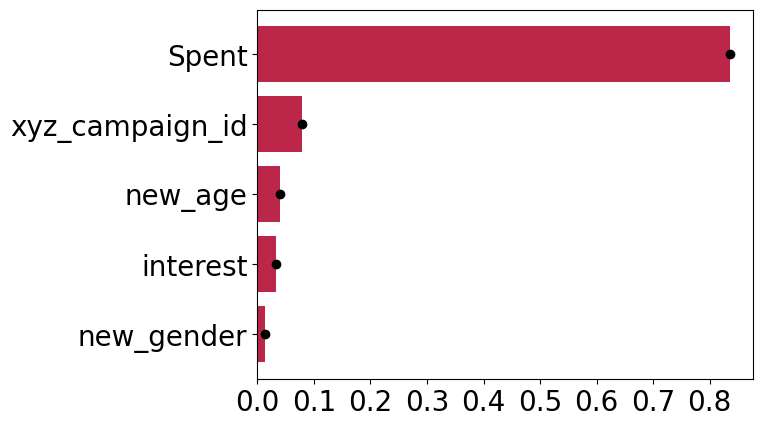

```python
import numpy as np
import pandas as pd
import matplotlib.pyplot as plt
importance = pd.DataFrame(list(zip(numericCols, rfModel.featureImportances)))
importance = importance.sort_values([1], ascending=True).reset_index(drop=True)

height = importance[1]
bars = importance[0]
y_pos = np.arange(len(bars))

# Create horizontal bars
plt.barh(y_pos, height, color='#bb2649')

# Create names on the x-axis
plt.yticks(y_pos, bars)

# Reorder it based on the values
my_range=importance[0]

# The horizontal plot is made using the hline function
# plt.hlines(y=my_range, xmin=0, xmax=importance[1], color='#bb2649', linewidth='4')
plt.plot(importance[1], my_range, "o", color='black')

plt.yticks(fontsize=20)
plt.xticks(fontsize=20)
```

### Clicks

```python
rf = RandomForestRegressor(featuresCol = 'features', labelCol = 'Clicks', numTrees=50, maxDepth=20, seed=42)
rfModel = rf.fit(train)
predictions = rfModel.transform(test)
predictions = predictions.withColumn("prediction", func.round(predictions["prediction"], 0))
```

```
23/02/15 00:24:46 WARN DAGScheduler: Broadcasting large task binary with size 1083.1 KiB
23/02/15 00:24:46 WARN DAGScheduler: Broadcasting large task binary with size 1508.9 KiB
23/02/15 00:24:46 WARN DAGScheduler: Broadcasting large task binary with size 1941.8 KiB
23/02/15 00:24:46 WARN DAGScheduler: Broadcasting large task binary with size 2.3 MiB
23/02/15 00:24:47 WARN DAGScheduler: Broadcasting large task binary with size 2.5 MiB
23/02/15 00:24:47 WARN DAGScheduler: Broadcasting large task binary with size 2.6 MiB
23/02/15 00:24:47 WARN DAGScheduler: Broadcasting large task binary with size 2.5 MiB
23/02/15 00:24:47 WARN DAGScheduler: Broadcasting large task binary with size 1782.6 KiB
```

```python
predictions = predictions.withColumn("prediction", func.round(predictions["prediction"], 0))
r2 = RegressionEvaluator(predictionCol="prediction", \
                 labelCol="Clicks",metricName="r2")
print("R Squared (R2) on test data = %g" % r2.evaluate(predictions))
```

```
R Squared (R2) on test data = 0.978314
```

```python
list(zip(numericCols, rfModel.featureImportances))
```

```
[('xyz_campaign_id', 0.1192289421260943),
 ('new_age', 0.028149120404000267),
 ('new_gender', 0.033557320709134544),
 ('interest', 0.035102220630379356),
 ('Spent', 0.7839623961303913)]
```

[output not shown]

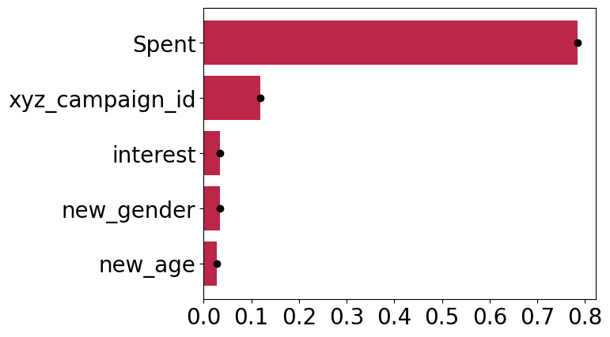

```python
import numpy as np
importance = pd.DataFrame(list(zip(numericCols, rfModel.featureImportances)))
importance = importance.sort_values([1], ascending=True).reset_index(drop=True)

height = importance[1]
bars = importance[0]
y_pos = np.arange(len(bars))

# Create horizontal bars
plt.barh(y_pos, height, color='#bb2649')

# Create names on the x-axis
plt.yticks(y_pos, bars)

# Reorder it based on the values
my_range=importance[0]

# The horizontal plot is made using the hline function
# plt.hlines(y=my_range, xmin=0, xmax=importance[1], color='#bb2649', linewidth='4')
plt.plot(importance[1], my_range, "o", color='black')

plt.yticks(fontsize=20)
plt.xticks(fontsize=20)
```

We can clearly see that Spent have the most effect on Clicks.

## Sales Conversion

### Total Conversion

```python
rf = RandomForestRegressor(featuresCol = 'features', labelCol = 'Total_Conversion', numTrees=10, maxDepth=10, seed=42)
rfModel = rf.fit(train)
predictions = rfModel.transform(test)
predictions = predictions.withColumn("prediction", func.round(predictions["prediction"], 0))
```

```python
predictions = predictions.withColumn("prediction", func.round(predictions["prediction"], 0))
r2 = RegressionEvaluator(predictionCol="prediction", \
                 labelCol="Total_Conversion",metricName="r2")
print("R Squared (R2) on test data = %g" % r2.evaluate(predictions))
```

```
R Squared (R2) on test data = 0.701334
```

```python
rfModel.featureImportances
```

```
SparseVector(5, {0: 0.0552, 1: 0.16, 2: 0.0342, 3: 0.1598, 4: 0.5908})
```

```python
list(zip(numericCols, rfModel.featureImportances))
```

```
[('xyz_campaign_id', 0.055172420324036464),
 ('new_age', 0.16000407294302185),
 ('new_gender', 0.03420567322623615),
 ('interest', 0.15981322115417285),
 ('Spent', 0.5908046123525325)]
```

[output not shown]

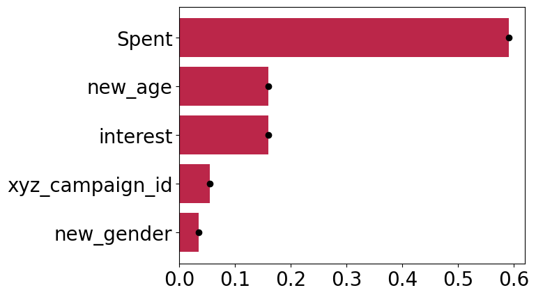

```python
import numpy as np
importance = pd.DataFrame(list(zip(numericCols, rfModel.featureImportances)))
importance = importance.sort_values([1], ascending=True).reset_index(drop=True)

height = importance[1]
bars = importance[0]
y_pos = np.arange(len(bars))

# Create horizontal bars
plt.barh(y_pos, height, color='#bb2649')

# Create names on the x-axis
plt.yticks(y_pos, bars)

# Reorder it based on the values
my_range=importance[0]

# The horizontal plot is made using the hline function
# plt.hlines(y=my_range, xmin=0, xmax=importance[1], color='#bb2649', linewidth='4')
plt.plot(importance[1], my_range, "o", color='black')

plt.yticks(fontsize=20)
plt.xticks(fontsize=20)
```

### Approved Conversion

```python
rf = RandomForestRegressor(featuresCol = 'features', labelCol = 'Approved_Conversion', numTrees=20, maxDepth=20, seed=42)
rfModel = rf.fit(train)
predictions = rfModel.transform(test)
predictions = predictions.withColumn("prediction", func.round(predictions["prediction"], 0))
```

```
23/02/15 00:24:52 WARN DAGScheduler: Broadcasting large task binary with size 1036.8 KiB
23/02/15 00:24:52 WARN DAGScheduler: Broadcasting large task binary with size 1086.6 KiB
23/02/15 00:24:52 WARN DAGScheduler: Broadcasting large task binary with size 1096.1 KiB
```

```python
predictions = predictions.withColumn("prediction", func.round(predictions["prediction"], 0))
r2 = RegressionEvaluator(predictionCol="prediction", \
                 labelCol="Approved_Conversion",metricName="r2")
print("R Squared (R2) on test data = %g" % r2.evaluate(predictions))
```

```
R Squared (R2) on test data = 0.536858
```

```python
rfModel.featureImportances
```

```
SparseVector(5, {0: 0.0569, 1: 0.1805, 2: 0.0706, 3: 0.211, 4: 0.481})
```

```python
list(zip(numericCols, rfModel.featureImportances))
```

```
[('xyz_campaign_id', 0.05688863029214454),
 ('new_age', 0.1804651153673665),
 ('new_gender', 0.0706081323147916),
 ('interest', 0.21103882552221037),
 ('Spent', 0.480999296503487)]
```

## Train a function to map the setting spaces to clicks

```python
from pyspark.ml.regression import RandomForestRegressor
import pyspark.sql.functions as func
from pyspark.ml.evaluation import RegressionEvaluator
from pyspark.ml.tuning import CrossValidator, ParamGridBuilder
from pyspark.ml import Pipeline
from pyspark import SparkContext
from pyspark.sql import SQLContext
from pyspark.sql import functions as F
from pyspark.sql.window import Window
```

```python
from pyspark.ml.feature import StringIndexer

stringIndexer = StringIndexer(inputCols=['age', 'gender'], outputCols=['new_age', 'new_gender'])
# Applying stringindexer object on dataframe movie title column
model  = stringIndexer.fit(df)
# Creating new dataframe with transformed values
indexed_df = model.transform(df)
# Validate the numerical title values
indexed_df.show(5)
```

```
+------+---------------+--------------+-----+------+--------+-----------+------+-----------+----------------+-------------------+-------+----------+
| ad_id|xyz_campaign_id|fb_campaign_id|  age|gender|interest|Impressions|Clicks|      Spent|Total_Conversion|Approved_Conversion|new_age|new_gender|
+------+---------------+--------------+-----+------+--------+-----------+------+-----------+----------------+-------------------+-------+----------+
|708746|            916|        103916|30-34|     M|      15|       7350|     1|1.429999948|               2|                  1|    0.0|       0.0|
|708749|            916|        103917|30-34|     M|      16|      17861|     2|1.820000023|               2|                  0|    0.0|       0.0|
|708771|            916|        103920|30-34|     M|      20|        693|     0|        0.0|               1|                  0|    0.0|       0.0|
|708815|            916|        103928|30-34|     M|      28|       4259|     1|       1.25|               1|                  0|    0.0|       0.0|
|708818|            916|        103928|30-34|     M|      28|       4133|     1|1.289999962|               1|                  1|    0.0|       0.0|
+------+---------------+--------------+-----+------+--------+-----------+------+-----------+----------------+-------------------+-------+----------+
only showing top 5 rows
```

```python
from pyspark.ml.feature import VectorAssembler

numericCols = ['xyz_campaign_id', 'new_age', 'new_gender', 'interest', 'Spent']
assembler = VectorAssembler(inputCols=numericCols, outputCol="features")
indexed_df = assembler.transform(indexed_df)
indexed_df.show()
```

```
+------+---------------+--------------+-----+------+--------+-----------+------+-----------+----------------+-------------------+-------+----------+--------------------+
| ad_id|xyz_campaign_id|fb_campaign_id|  age|gender|interest|Impressions|Clicks|      Spent|Total_Conversion|Approved_Conversion|new_age|new_gender|            features|
+------+---------------+--------------+-----+------+--------+-----------+------+-----------+----------------+-------------------+-------+----------+--------------------+
|708746|            916|        103916|30-34|     M|      15|       7350|     1|1.429999948|               2|                  1|    0.0|       0.0|[916.0,0.0,0.0,15...|
|708749|            916|        103917|30-34|     M|      16|      17861|     2|1.820000023|               2|                  0|    0.0|       0.0|[916.0,0.0,0.0,16...|
|708771|            916|        103920|30-34|     M|      20|        693|     0|        0.0|               1|                  0|    0.0|       0.0|(5,[0,3],[916.0,2...|
|708815|            916|        103928|30-34|     M|      28|       4259|     1|       1.25|               1|                  0|    0.0|       0.0|[916.0,0.0,0.0,28...|
|708818|            916|        103928|30-34|     M|      28|       4133|     1|1.289999962|               1|                  1|    0.0|       0.0|[916.0,0.0,0.0,28...|
|708820|            916|        103929|30-34|     M|      29|       1915|     0|        0.0|               1|                  1|    0.0|       0.0|(5,[0,3],[916.0,2...|
|708889|            916|        103940|30-34|     M|      15|      15615|     3|4.769999981|               1|                  0|    0.0|       0.0|[916.0,0.0,0.0,15...|
|708895|            916|        103941|30-34|     M|      16|      10951|     1|1.269999981|               1|                  1|    0.0|       0.0|[916.0,0.0,0.0,16...|
|708953|            916|        103951|30-34|     M|      27|       2355|     1|        1.5|               1|                  0|    0.0|       0.0|[916.0,0.0,0.0,27...|
|708958|            916|        103952|30-34|     M|      28|       9502|     3|3.159999967|               1|                  0|    0.0|       0.0|[916.0,0.0,0.0,28...|
|708979|            916|        103955|30-34|     M|      31|       1224|     0|        0.0|               1|                  0|    0.0|       0.0|(5,[0,3],[916.0,3...|
|709023|            916|        103962|30-34|     M|       7|        735|     0|        0.0|               1|                  0|    0.0|       0.0|(5,[0,3],[916.0,7...|
|709038|            916|        103965|30-34|     M|      16|       5117|     0|        0.0|               1|                  0|    0.0|       0.0|(5,[0,3],[916.0,1...|
|709040|            916|        103965|30-34|     M|      16|       5120|     0|        0.0|               1|                  0|    0.0|       0.0|(5,[0,3],[916.0,1...|
|709059|            916|        103968|30-34|     M|      20|      14669|     7|10.28000021|               1|                  1|    0.0|       0.0|[916.0,0.0,0.0,20...|
|709105|            916|        103976|30-34|     M|      28|       1241|     0|        0.0|               1|                  1|    0.0|       0.0|(5,[0,3],[916.0,2...|
|709115|            916|        103978|30-34|     M|      30|       2305|     1|0.569999993|               1|                  0|    0.0|       0.0|[916.0,0.0,0.0,30...|
|709124|            916|        103979|30-34|     M|      31|       1024|     0|        0.0|               1|                  1|    0.0|       0.0|(5,[0,3],[916.0,3...|
|709179|            916|        103988|35-39|     M|      15|       4627|     1|1.690000057|               1|                  0|    2.0|       0.0|[916.0,2.0,0.0,15...|
|709183|            916|        103989|35-39|     M|      16|      21026|     4|4.630000114|               2|                  1|    2.0|       0.0|[916.0,2.0,0.0,16...|
+------+---------------+--------------+-----+------+--------+-----------+------+-----------+----------------+-------------------+-------+----------+--------------------+
only showing top 20 rows
```

```python
train, val = indexed_df.randomSplit([0.8, 0.2], seed = 0)
```

```python
rf = RandomForestRegressor(featuresCol = 'features', labelCol = 'Clicks',  numTrees=50, maxDepth=20, seed=42)
rfModel = rf.fit(train)
predictions = rfModel.transform(val)
predictions = predictions.withColumn("prediction", func.round(predictions["prediction"], 0))
```

```
23/02/15 00:24:55 WARN DAGScheduler: Broadcasting large task binary with size 1083.3 KiB
23/02/15 00:24:55 WARN DAGScheduler: Broadcasting large task binary with size 1509.1 KiB
23/02/15 00:24:55 WARN DAGScheduler: Broadcasting large task binary with size 1942.0 KiB
23/02/15 00:24:56 WARN DAGScheduler: Broadcasting large task binary with size 2.3 MiB
23/02/15 00:24:56 WARN DAGScheduler: Broadcasting large task binary with size 2.5 MiB
23/02/15 00:24:56 WARN DAGScheduler: Broadcasting large task binary with size 2.6 MiB
23/02/15 00:24:56 WARN DAGScheduler: Broadcasting large task binary with size 2.5 MiB
23/02/15 00:24:56 WARN DAGScheduler: Broadcasting large task binary with size 1782.8 KiB
```

```python
predictions = predictions.withColumn("prediction", func.round(predictions["prediction"], 0))
r2 = RegressionEvaluator(predictionCol="prediction", \
                 labelCol="Clicks",metricName="r2")
print("R Squared (R2) on test data = %g" % r2.evaluate(predictions))
```

```
R Squared (R2) on test data = 0.978314
```

```python
def map_click(setting, budget, predictor):
    test_pd = pd.DataFrame({
      'xyz_campaign_id': [setting['xyz_campaign_id']]*len(budget),

      'age': [setting['age']]*len(budget),

      'gender': [setting['gender']]*len(budget),

      'interest': [setting['interest']]*len(budget),

      'Spent': budget
      })

    test = spark.createDataFrame(test_pd)

    numericCols = ['xyz_campaign_id', 'age', 'gender', 'interest', 'Spent']
    assembler = VectorAssembler(inputCols=numericCols, outputCol="features")
    test = assembler.transform(test)

    predictions = predictor.transform(test)
    predictions = predictions.withColumn("prediction", func.round(predictions["prediction"], 0))

    sns.set_style("white")
    sns.lineplot(data=predictions.toPandas(), x="Spent", y="prediction", color="#bb2649")

    test.createOrReplaceTempView("test")

    my_window = Window.partitionBy().orderBy("Spent")

    predictions = predictions.withColumn("prev_prediction", F.lag(predictions.prediction).over(my_window))
    predictions = predictions.withColumn("diff", F.when(F.isnull(predictions.prediction - predictions.prev_prediction), 0)
                                  .otherwise(predictions.prediction - predictions.prev_prediction))

    predictions.createOrReplaceTempView("predictions")
    res = spark.sql("SELECT Spent, prediction, diff FROM predictions WHERE diff = (SELECT MAX(diff) FROM predictions)")
    res.show()

    return res.collect()[0]['Spent']
```

```
23/02/15 00:24:59 WARN WindowExec: No Partition Defined for Window operation! Moving all data to a single partition, this can cause serious performance degradation.
23/02/15 00:24:59 WARN WindowExec: No Partition Defined for Window operation! Moving all data to a single partition, this can cause serious performance degradation.
23/02/15 00:24:59 WARN WindowExec: No Partition Defined for Window operation! Moving all data to a single partition, this can cause serious performance degradation.
23/02/15 00:24:59 WARN WindowExec: No Partition Defined for Window operation! Moving all data to a single partition, this can cause serious performance degradation.
23/02/15 00:24:59 WARN WindowExec: No Partition Defined for Window operation! Moving all data to a single partition, this can cause serious performance degradation.
23/02/15 00:24:59 WARN WindowExec: No Partition Defined for Window operation! Moving all data to a single partition, this can cause serious performance degradation.
+-----+----------+-----+
|Spent|prediction| diff|
+-----+----------+-----+
|  292|     198.0|105.0|
+-----+----------+-----+

23/02/15 00:24:59 WARN WindowExec: No Partition Defined for Window operation! Moving all data to a single partition, this can cause serious performance degradation.
23/02/15 00:24:59 WARN WindowExec: No Partition Defined for Window operation! Moving all data to a single partition, this can cause serious performance degradation.
23/02/15 00:24:59 WARN WindowExec: No Partition Defined for Window operation! Moving all data to a single partition, this can cause serious performance degradation.
23/02/15 00:24:59 WARN WindowExec: No Partition Defined for Window operation! Moving all data to a single partition, this can cause serious performance degradation.
23/02/15 00:25:00 WARN WindowExec: No Partition Defined for Window operation! Moving all data to a single partition, this can cause serious performance degradation.
23/02/15 00:25:00 WARN WindowExec: No Partition Defined for Window operation! Moving all data to a single partition, this can cause serious performance degradation.
```

```
292
```

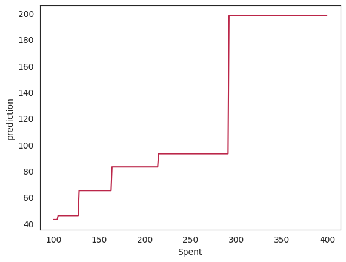

```python
import seaborn as sns
setting = {'xyz_campaign_id': 916.0,
           'age': 0.0,
           'gender': 0.0,
           'interest': 15}
budget = [i for i in range(100,400,1)]
map_click(setting, budget, rfModel)
```

## Feature Engineering

### Adding conversions features

- Spent per Click: Cost per Click (CPC)
- Click per Impression: Click through rate (CTR)
- Total/Approved Conversion per Impression ((A)CR)
- Approved Conversion per Total Conversion (AR)

We also want to include the cost per conversion, however some spent = 0 yet having positive conversion, so we did not include this measure.

```python
df = df.withColumn('CPC', df['Spent'] / df['Clicks'])
df = df.withColumn('CTR', df['Clicks']*100 / df['Impressions'])
df = df.withColumn('TCR', df['Total_Conversion']*100 / df['Impressions'])
df = df.withColumn('ACR', df['Approved_Conversion']*100 / df['Impressions'])
df = df.withColumn('AR', df['Approved_Conversion']*100 / df['Total_Conversion'])
```

```python
df=df.na.fill(value=10,subset=["CPC"])
```

```python
df.createOrReplaceTempView("df")
```

```python
df.show(10)
```

```
+------+---------------+--------------+-----+------+--------+-----------+------+-----------+----------------+-------------------+------------------+--------------------+--------------------+--------------------+-----+
| ad_id|xyz_campaign_id|fb_campaign_id|  age|gender|interest|Impressions|Clicks|      Spent|Total_Conversion|Approved_Conversion|               CPC|                 CTR|                 TCR|                 ACR|   AR|
+------+---------------+--------------+-----+------+--------+-----------+------+-----------+----------------+-------------------+------------------+--------------------+--------------------+--------------------+-----+
|708746|            916|        103916|30-34|     M|      15|       7350|     1|1.429999948|               2|                  1|       1.429999948|0.013605442176870748|0.027210884353741496|0.013605442176870748| 50.0|
|708749|            916|        103917|30-34|     M|      16|      17861|     2|1.820000023|               2|                  0|      0.9100000115|0.011197581322434353|0.011197581322434353|                 0.0|  0.0|
|708771|            916|        103920|30-34|     M|      20|        693|     0|        0.0|               1|                  0|              10.0|                 0.0|  0.1443001443001443|                 0.0|  0.0|
|708815|            916|        103928|30-34|     M|      28|       4259|     1|       1.25|               1|                  0|              1.25|  0.0234796900680911|  0.0234796900680911|                 0.0|  0.0|
|708818|            916|        103928|30-34|     M|      28|       4133|     1|1.289999962|               1|                  1|       1.289999962|0.024195499637067505|0.024195499637067505|0.024195499637067505|100.0|
|708820|            916|        103929|30-34|     M|      29|       1915|     0|        0.0|               1|                  1|              10.0|                 0.0| 0.05221932114882506| 0.05221932114882506|100.0|
|708889|            916|        103940|30-34|     M|      15|      15615|     3|4.769999981|               1|                  0|1.5899999936666667| 0.01921229586935639|0.006404098623118796|                 0.0|  0.0|
|708895|            916|        103941|30-34|     M|      16|      10951|     1|1.269999981|               1|                  1|       1.269999981|0.009131586156515386|0.009131586156515386|0.009131586156515386|100.0|
|708953|            916|        103951|30-34|     M|      27|       2355|     1|        1.5|               1|                  0|               1.5| 0.04246284501061571| 0.04246284501061571|                 0.0|  0.0|
|708958|            916|        103952|30-34|     M|      28|       9502|     3|3.159999967|               1|                  0|1.0533333223333334| 0.03157230056830141|0.010524100189433803|                 0.0|  0.0|
+------+---------------+--------------+-----+------+--------+-----------+------+-----------+----------------+-------------------+------------------+--------------------+--------------------+--------------------+-----+
only showing top 10 rows
```

### EDA for addiontal features

[output not shown]

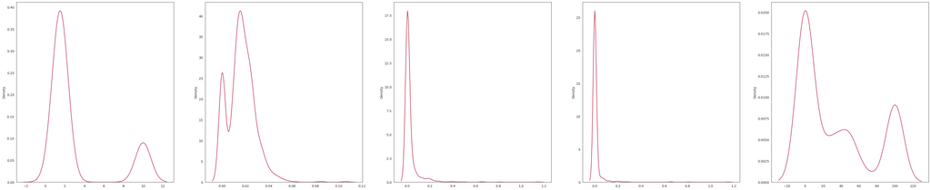

```python
labels = []
i = 0
fig, axs = plt.subplots(1, 5, figsize=(50, 10))
for feat in ['CPC', 'CTR', 'TCR', 'ACR', 'AR']:
  x = spark.sql("SELECT {0} \
            FROM df".format(feat)).toPandas()
  labels.append(feat)
  sns.distplot(a=x, hist=False, kde=True, norm_hist=True, ax=axs[i], color='#BB2649')
  i += 1
```

[output not shown]

[output cut: 110 more lines]

[output not shown]

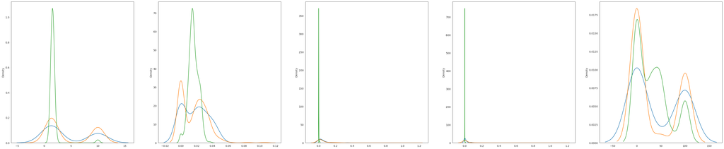

```python
labels = []
i = 0
fig, axs = plt.subplots(1, 5, figsize=(50, 10))
for feat in ['CPC', 'CTR', 'TCR', 'ACR', 'AR']:
  for cp in ['916', '936', '1178']:
    x = spark.sql("SELECT {0} \
              FROM df \
              WHERE xyz_campaign_id = '{1}'".format(feat, cp)).toPandas()
    sns.distplot(a=x, hist=False, kde=True, ax=axs[i])
  i += 1
```

[output not shown]

[output cut: 55 more lines]

[output not shown]

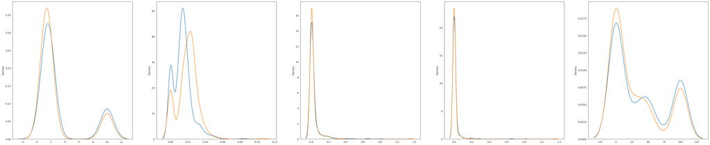

```python
labels = []
i = 0
fig, axs = plt.subplots(1, 5, figsize=(50, 10))
for feat in ['CPC', 'CTR', 'TCR', 'ACR', 'AR']:
  for gender in ['M', 'F']:
    x = spark.sql("SELECT {0} \
              FROM df \
              WHERE GENDER = '{1}'".format(feat, gender)).toPandas()
    sns.distplot(a=x, hist=False, kde=True, ax=axs[i])
  i += 1
```

[output not shown]

[output cut: 165 more lines]

[output not shown]

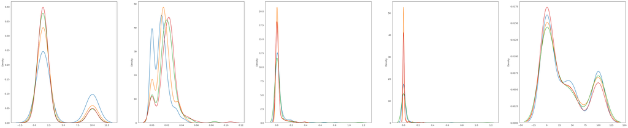

```python
labels = []
i = 0
fig, axs = plt.subplots(1, 5, figsize=(50, 10))
for feat in ['CPC', 'CTR', 'TCR', 'ACR', 'AR']:
  for age in ['30-34', '35-39', '40-44', '45-49']:
    x = spark.sql("SELECT {0} \
              FROM df \
              WHERE AGE = '{1}'".format(feat, age)).toPandas()
    sns.distplot(a=x, hist=False, kde=True, ax=axs[i])
  i += 1
```

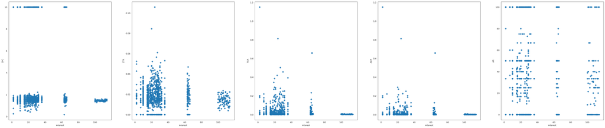

```python
labels = []
i = 0
fig, axs = plt.subplots(1, 5, figsize=(50, 10))
for feat in ['CPC', 'CTR', 'TCR', 'ACR', 'AR']:
  labels.append(feat)
  sns.regplot(y=df.toPandas()[feat], x=df.toPandas()["interest"], ax=axs[i],fit_reg=False)
  i += 1
```

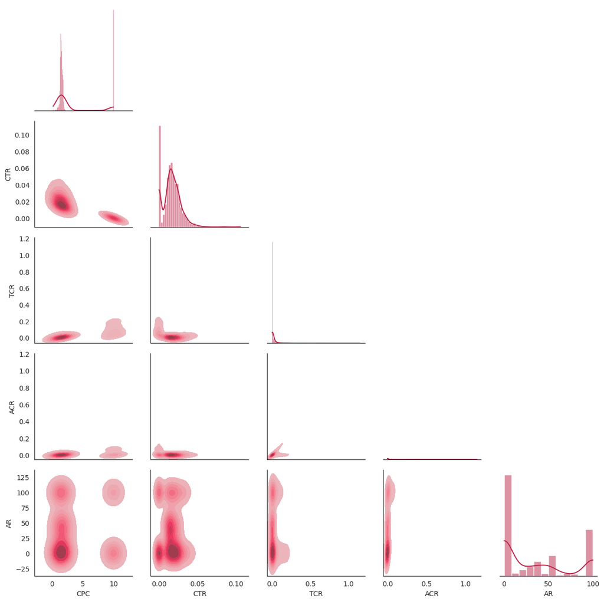

```python
g=sns.PairGrid(df.toPandas(), vars=['CPC', 'CTR', 'TCR', 'ACR', 'AR'], diag_sharey=False, corner=True)
g.map_lower(sns.kdeplot, color="#BB2649", fill=True)
g.map_diag(sns.histplot, color="#BB2649", kde=True)
```

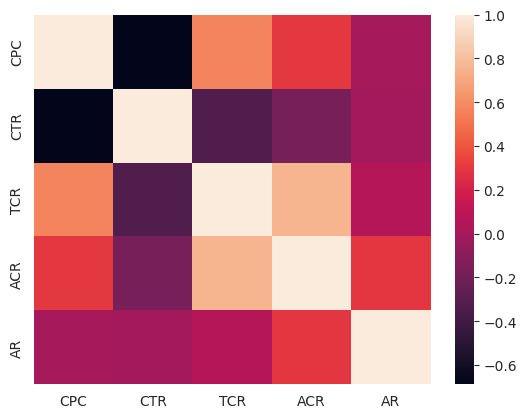

```python
sns.heatmap(df.select(['CPC', 'CTR', 'TCR', 'ACR', 'AR']).toPandas().corr())
```

## Algorithm 2: Classifying potential customers

```python
df_avg = spark.sql("SELECT xyz_campaign_id, fb_campaign_id, age, gender, interest, \
 AVG(CPC) CPC, AVG(CTR) CTR, AVG(TCR) TCR, AVG(ACR) ACR, AVG(AR) AR FROM df GROUP BY xyz_campaign_id, fb_campaign_id, age, gender, interest")
```

```python
df_avg.show()
```

```
+---------------+--------------+-----+------+--------+------------------+--------------------+--------------------+--------------------+------------------+
|xyz_campaign_id|fb_campaign_id|  age|gender|interest|               CPC|                 CTR|                 TCR|                 ACR|                AR|
+---------------+--------------+-----+------+--------+------------------+--------------------+--------------------+--------------------+------------------+
|           1178|        144558|30-34|     M|      31| 4.534666637333333|0.005916937489302277|0.004178901162029121|6.627168740970484E-4|16.666666666666668|
|           1178|        144630|45-49|     M|      23|1.7526983947222223|0.015786107666691668|0.002385181096414234|                 0.0|               0.0|
|            936|        108826|45-49|     F|      19|              10.0|                 0.0| 0.18867924528301888|                 0.0|               0.0|
|            916|        104109|40-44|     M|      16|1.2100000211428572|0.029390771297812486|0.004198681613973213|0.004198681613973213|             100.0|
|            936|        116220|30-34|     F|      63|       1.370000005|0.016194331983805668|0.032388663967611336|0.016194331983805668|              50.0|
|           1178|        144601|40-44|     M|      19|1.7861717850124268| 0.01657790701466242|0.001652937162066...|  9.5079805723351E-4| 49.20634920634921|
|           1178|        144692|35-39|     F|      64| 1.250705156923833|0.024033107237750685|0.002385829723640...|7.648159132594469E-4|              32.5|
|            936|        108716|40-44|     M|      29|       0.660000026| 0.02594370216629913| 0.02594370216629913|                 0.0|               0.0|
|            936|        109452|30-34|     M|      16|              10.0|                 0.0|0.027878449958182325|                 0.0|               0.0|
|            936|        115535|45-49|     M|      64|1.5799999833333331| 0.03100294527980158|0.005167157546633597|0.005167157546633597|             100.0|
|           1178|        144547|30-34|     M|      26|1.7226022778585857|0.009810998140586669|0.003523198063881...|                 0.0|               0.0|
|           1178|        144628|45-49|     M|      21|1.6100270405590829|0.016076913826844032|0.001752092817991...|                 0.0|               0.0|
|            936|        108817|40-44|     F|      63|       1.450000048|0.022665457842248413|0.022665457842248413|                 0.0|               0.0|
|            936|        110836|30-34|     M|      10|     5.79750001425|0.013873473917869035|0.035573621265921916|                 0.0|               0.0|
|            936|        115625|30-34|     M|      63|              10.0|                 0.0|  0.0419639110365086|  0.0419639110365086|             100.0|
|            936|        116405|30-34|     F|      32|              10.0|                 0.0|0.056259329078619365|                 0.0|               0.0|
|           1178|        144585|35-39|     M|      28|1.7778482067891879|0.015098318194193808| 6.49053516492285E-4|1.347230039967253...|18.545454545454547|
|           1178|        144592|35-39|     M|      64|1.7584077635781838|0.012832982100027934|0.001943080996343...|5.750972276420813E-4|              40.0|
|           1178|        144672|35-39|     F|      10| 1.422398421578053|0.021480063313965164|0.001502282023529201|2.442836417432834E-4|11.458333333333334|
|            936|        115563|45-49|     M|      21|              10.0|                 0.0|0.062150403977625855|                 0.0|               0.0|
+---------------+--------------+-----+------+--------+------------------+--------------------+--------------------+--------------------+------------------+
only showing top 20 rows
```

### Clustering based on CTR, CPC

We can see that there are 2 modes in the CTR, hence we first bring this to an unsupervised task. We try to cluster the customers into 2 clusters, using (CPC, CTR) which are variables related to sales/revenue.

```python
from pyspark.ml.feature import VectorAssembler
assemble=VectorAssembler(inputCols=['CPC', 'CTR'], outputCol='features')
assembled_data=assemble.transform(df)
```

```python
assembled_data.show()
```

```
+------+---------------+--------------+-----+------+--------+-----------+------+-----------+----------------+-------------------+------------------+--------------------+--------------------+--------------------+-----+--------------------+
| ad_id|xyz_campaign_id|fb_campaign_id|  age|gender|interest|Impressions|Clicks|      Spent|Total_Conversion|Approved_Conversion|               CPC|                 CTR|                 TCR|                 ACR|   AR|            features|
+------+---------------+--------------+-----+------+--------+-----------+------+-----------+----------------+-------------------+------------------+--------------------+--------------------+--------------------+-----+--------------------+
|708746|            916|        103916|30-34|     M|      15|       7350|     1|1.429999948|               2|                  1|       1.429999948|0.013605442176870748|0.027210884353741496|0.013605442176870748| 50.0|[1.429999948,0.01...|
|708749|            916|        103917|30-34|     M|      16|      17861|     2|1.820000023|               2|                  0|      0.9100000115|0.011197581322434353|0.011197581322434353|                 0.0|  0.0|[0.9100000115,0.0...|
|708771|            916|        103920|30-34|     M|      20|        693|     0|        0.0|               1|                  0|              10.0|                 0.0|  0.1443001443001443|                 0.0|  0.0|          [10.0,0.0]|
|708815|            916|        103928|30-34|     M|      28|       4259|     1|       1.25|               1|                  0|              1.25|  0.0234796900680911|  0.0234796900680911|                 0.0|  0.0|[1.25,0.023479690...|
|708818|            916|        103928|30-34|     M|      28|       4133|     1|1.289999962|               1|                  1|       1.289999962|0.024195499637067505|0.024195499637067505|0.024195499637067505|100.0|[1.289999962,0.02...|
|708820|            916|        103929|30-34|     M|      29|       1915|     0|        0.0|               1|                  1|              10.0|                 0.0| 0.05221932114882506| 0.05221932114882506|100.0|          [10.0,0.0]|
|708889|            916|        103940|30-34|     M|      15|      15615|     3|4.769999981|               1|                  0|1.5899999936666667| 0.01921229586935639|0.006404098623118796|                 0.0|  0.0|[1.58999999366666...|
|708895|            916|        103941|30-34|     M|      16|      10951|     1|1.269999981|               1|                  1|       1.269999981|0.009131586156515386|0.009131586156515386|0.009131586156515386|100.0|[1.269999981,0.00...|
|708953|            916|        103951|30-34|     M|      27|       2355|     1|        1.5|               1|                  0|               1.5| 0.04246284501061571| 0.04246284501061571|                 0.0|  0.0|[1.5,0.0424628450...|
|708958|            916|        103952|30-34|     M|      28|       9502|     3|3.159999967|               1|                  0|1.0533333223333334| 0.03157230056830141|0.010524100189433803|                 0.0|  0.0|[1.05333332233333...|
|708979|            916|        103955|30-34|     M|      31|       1224|     0|        0.0|               1|                  0|              10.0|                 0.0| 0.08169934640522876|                 0.0|  0.0|          [10.0,0.0]|
|709023|            916|        103962|30-34|     M|       7|        735|     0|        0.0|               1|                  0|              10.0|                 0.0|  0.1360544217687075|                 0.0|  0.0|          [10.0,0.0]|
|709038|            916|        103965|30-34|     M|      16|       5117|     0|        0.0|               1|                  0|              10.0|                 0.0|0.019542700801250732|                 0.0|  0.0|          [10.0,0.0]|
|709040|            916|        103965|30-34|     M|      16|       5120|     0|        0.0|               1|                  0|              10.0|                 0.0|          0.01953125|                 0.0|  0.0|          [10.0,0.0]|
|709059|            916|        103968|30-34|     M|      20|      14669|     7|10.28000021|               1|                  1|1.4685714585714287|  0.0477196809598473|0.006817097279978185|0.006817097279978185|100.0|[1.46857145857142...|
|709105|            916|        103976|30-34|     M|      28|       1241|     0|        0.0|               1|                  1|              10.0|                 0.0| 0.08058017727639001| 0.08058017727639001|100.0|          [10.0,0.0]|
|709115|            916|        103978|30-34|     M|      30|       2305|     1|0.569999993|               1|                  0|       0.569999993| 0.04338394793926247| 0.04338394793926247|                 0.0|  0.0|[0.569999993,0.04...|
|709124|            916|        103979|30-34|     M|      31|       1024|     0|        0.0|               1|                  1|              10.0|                 0.0|          0.09765625|          0.09765625|100.0|          [10.0,0.0]|
|709179|            916|        103988|35-39|     M|      15|       4627|     1|1.690000057|               1|                  0|       1.690000057| 0.02161227577263886| 0.02161227577263886|                 0.0|  0.0|[1.690000057,0.02...|
|709183|            916|        103989|35-39|     M|      16|      21026|     4|4.630000114|               2|                  1|      1.1575000285|0.019024065442785124|0.009512032721392562|0.004756016360696281| 50.0|[1.1575000285,0.0...|
+------+---------------+--------------+-----+------+--------+-----------+------+-----------+----------------+-------------------+------------------+--------------------+--------------------+--------------------+-----+--------------------+
only showing top 20 rows
```

```python
from pyspark.ml.feature import StandardScaler
scale=StandardScaler(inputCol='features',outputCol='standardized')
data_scale=scale.fit(assembled_data)
data_scale_output=data_scale.transform(assembled_data)
data_scale_output.show()
```

```
+------+---------------+--------------+-----+------+--------+-----------+------+-----------+----------------+-------------------+------------------+--------------------+--------------------+--------------------+-----+--------------------+--------------------+
| ad_id|xyz_campaign_id|fb_campaign_id|  age|gender|interest|Impressions|Clicks|      Spent|Total_Conversion|Approved_Conversion|               CPC|                 CTR|                 TCR|                 ACR|   AR|            features|        standardized|
+------+---------------+--------------+-----+------+--------+-----------+------+-----------+----------------+-------------------+------------------+--------------------+--------------------+--------------------+-----+--------------------+--------------------+
|708746|            916|        103916|30-34|     M|      15|       7350|     1|1.429999948|               2|                  1|       1.429999948|0.013605442176870748|0.027210884353741496|0.013605442176870748| 50.0|[1.429999948,0.01...|[0.43573230713063...|
|708749|            916|        103917|30-34|     M|      16|      17861|     2|1.820000023|               2|                  0|      0.9100000115|0.011197581322434353|0.011197581322434353|                 0.0|  0.0|[0.9100000115,0.0...|[0.27728420903397...|
|708771|            916|        103920|30-34|     M|      20|        693|     0|        0.0|               1|                  0|              10.0|                 0.0|  0.1443001443001443|                 0.0|  0.0|          [10.0,0.0]|[3.04707918164648...|
|708815|            916|        103928|30-34|     M|      28|       4259|     1|       1.25|               1|                  0|              1.25|  0.0234796900680911|  0.0234796900680911|                 0.0|  0.0|[1.25,0.023479690...|[0.38088489770581...|
|708818|            916|        103928|30-34|     M|      28|       4133|     1|1.289999962|               1|                  1|       1.289999962|0.024195499637067505|0.024195499637067505|0.024195499637067505|100.0|[1.289999962,0.02...|[0.39307320285349...|
|708820|            916|        103929|30-34|     M|      29|       1915|     0|        0.0|               1|                  1|              10.0|                 0.0| 0.05221932114882506| 0.05221932114882506|100.0|          [10.0,0.0]|[3.04707918164648...|
|708889|            916|        103940|30-34|     M|      15|      15615|     3|4.769999981|               1|                  0|1.5899999936666667| 0.01921229586935639|0.006404098623118796|                 0.0|  0.0|[1.58999999366666...|[0.48448558795197...|
|708895|            916|        103941|30-34|     M|      16|      10951|     1|1.269999981|               1|                  1|       1.269999981|0.009131586156515386|0.009131586156515386|0.009131586156515386|100.0|[1.269999981,0.00...|[0.38697905027965...|
|708953|            916|        103951|30-34|     M|      27|       2355|     1|        1.5|               1|                  0|               1.5| 0.04246284501061571| 0.04246284501061571|                 0.0|  0.0|[1.5,0.0424628450...|[0.45706187724697...|
|708958|            916|        103952|30-34|     M|      28|       9502|     3|3.159999967|               1|                  0|1.0533333223333334| 0.03157230056830141|0.010524100189433803|                 0.0|  0.0|[1.05333332233333...|[0.32095900378164...|
|708979|            916|        103955|30-34|     M|      31|       1224|     0|        0.0|               1|                  0|              10.0|                 0.0| 0.08169934640522876|                 0.0|  0.0|          [10.0,0.0]|[3.04707918164648...|
|709023|            916|        103962|30-34|     M|       7|        735|     0|        0.0|               1|                  0|              10.0|                 0.0|  0.1360544217687075|                 0.0|  0.0|          [10.0,0.0]|[3.04707918164648...|
|709038|            916|        103965|30-34|     M|      16|       5117|     0|        0.0|               1|                  0|              10.0|                 0.0|0.019542700801250732|                 0.0|  0.0|          [10.0,0.0]|[3.04707918164648...|
```

[output cut: 9 more lines]

```python
from pyspark.ml.clustering import KMeans
from pyspark.ml.evaluation import ClusteringEvaluator
silhouette_score=[]
evaluator = ClusteringEvaluator(predictionCol='prediction', featuresCol='standardized', \
                                metricName='silhouette', distanceMeasure='squaredEuclidean')

KMeans_algo=KMeans(featuresCol='standardized', k=2)

KMeans_fit=KMeans_algo.fit(data_scale_output)

output=KMeans_fit.transform(data_scale_output)

score=evaluator.evaluate(output)
```

```python
output.show()
```

```
+------+---------------+--------------+-----+------+--------+-----------+------+-----------+----------------+-------------------+------------------+--------------------+--------------------+--------------------+-----+--------------------+--------------------+----------+
| ad_id|xyz_campaign_id|fb_campaign_id|  age|gender|interest|Impressions|Clicks|      Spent|Total_Conversion|Approved_Conversion|               CPC|                 CTR|                 TCR|                 ACR|   AR|            features|        standardized|prediction|
+------+---------------+--------------+-----+------+--------+-----------+------+-----------+----------------+-------------------+------------------+--------------------+--------------------+--------------------+-----+--------------------+--------------------+----------+
|708746|            916|        103916|30-34|     M|      15|       7350|     1|1.429999948|               2|                  1|       1.429999948|0.013605442176870748|0.027210884353741496|0.013605442176870748| 50.0|[1.429999948,0.01...|[0.43573230713063...|         0|
|708749|            916|        103917|30-34|     M|      16|      17861|     2|1.820000023|               2|                  0|      0.9100000115|0.011197581322434353|0.011197581322434353|                 0.0|  0.0|[0.9100000115,0.0...|[0.27728420903397...|         0|
|708771|            916|        103920|30-34|     M|      20|        693|     0|        0.0|               1|                  0|              10.0|                 0.0|  0.1443001443001443|                 0.0|  0.0|          [10.0,0.0]|[3.04707918164648...|         1|
|708815|            916|        103928|30-34|     M|      28|       4259|     1|       1.25|               1|                  0|              1.25|  0.0234796900680911|  0.0234796900680911|                 0.0|  0.0|[1.25,0.023479690...|[0.38088489770581...|         0|
|708818|            916|        103928|30-34|     M|      28|       4133|     1|1.289999962|               1|                  1|       1.289999962|0.024195499637067505|0.024195499637067505|0.024195499637067505|100.0|[1.289999962,0.02...|[0.39307320285349...|         0|
|708820|            916|        103929|30-34|     M|      29|       1915|     0|        0.0|               1|                  1|              10.0|                 0.0| 0.05221932114882506| 0.05221932114882506|100.0|          [10.0,0.0]|[3.04707918164648...|         1|
|708889|            916|        103940|30-34|     M|      15|      15615|     3|4.769999981|               1|                  0|1.5899999936666667| 0.01921229586935639|0.006404098623118796|                 0.0|  0.0|[1.58999999366666...|[0.48448558795197...|         0|
|708895|            916|        103941|30-34|     M|      16|      10951|     1|1.269999981|               1|                  1|       1.269999981|0.009131586156515386|0.009131586156515386|0.009131586156515386|100.0|[1.269999981,0.00...|[0.38697905027965...|         0|
|708953|            916|        103951|30-34|     M|      27|       2355|     1|        1.5|               1|                  0|               1.5| 0.04246284501061571| 0.04246284501061571|                 0.0|  0.0|[1.5,0.0424628450...|[0.45706187724697...|         0|
|708958|            916|        103952|30-34|     M|      28|       9502|     3|3.159999967|               1|                  0|1.0533333223333334| 0.03157230056830141|0.010524100189433803|                 0.0|  0.0|[1.05333332233333...|[0.32095900378164...|         0|
|708979|            916|        103955|30-34|     M|      31|       1224|     0|        0.0|               1|                  0|              10.0|                 0.0| 0.08169934640522876|                 0.0|  0.0|          [10.0,0.0]|[3.04707918164648...|         1|
|709023|            916|        103962|30-34|     M|       7|        735|     0|        0.0|               1|                  0|              10.0|                 0.0|  0.1360544217687075|                 0.0|  0.0|          [10.0,0.0]|[3.04707918164648...|         1|
|709038|            916|        103965|30-34|     M|      16|       5117|     0|        0.0|               1|                  0|              10.0|                 0.0|0.019542700801250732|                 0.0|  0.0|          [10.0,0.0]|[3.04707918164648...|         1|
```

[output cut: 9 more lines]

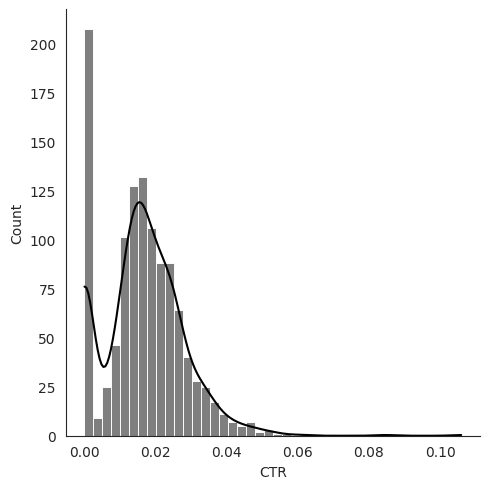

```python
sns.displot(data=output.select('CTR', 'prediction').toPandas(), x='CTR', kde=True, color ='#000000')
```

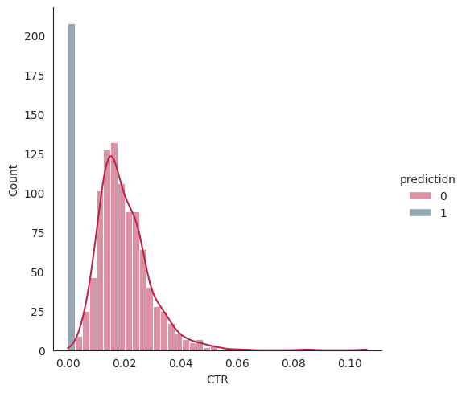

```python
sns.displot(data=output.select('CTR', 'prediction').toPandas(), x='CTR', kde=True, hue='prediction', palette =['#BB2649','#2B526B'])
```

### Clustering based on AR

We can see that there are 3 modes in the AR, hence we first bring this to an unsupervised task. We try to cluster the customers into 3 clusters, using (AR) which are variables related to sales/revenue.

```python
df_ar_drop = df.na.drop(subset=["AR"])
```

```python
from pyspark.ml.feature import VectorAssembler
assemble=VectorAssembler(inputCols=['AR'], outputCol='features')
assembled_data=assemble.transform(df_ar_drop)
```

```python
assembled_data.show()
```

```
+------+---------------+--------------+-----+------+--------+-----------+------+-----------+----------------+-------------------+------------------+--------------------+--------------------+--------------------+-----+--------+
| ad_id|xyz_campaign_id|fb_campaign_id|  age|gender|interest|Impressions|Clicks|      Spent|Total_Conversion|Approved_Conversion|               CPC|                 CTR|                 TCR|                 ACR|   AR|features|
+------+---------------+--------------+-----+------+--------+-----------+------+-----------+----------------+-------------------+------------------+--------------------+--------------------+--------------------+-----+--------+
|708746|            916|        103916|30-34|     M|      15|       7350|     1|1.429999948|               2|                  1|       1.429999948|0.013605442176870748|0.027210884353741496|0.013605442176870748| 50.0|  [50.0]|
|708749|            916|        103917|30-34|     M|      16|      17861|     2|1.820000023|               2|                  0|      0.9100000115|0.011197581322434353|0.011197581322434353|                 0.0|  0.0|   [0.0]|
|708771|            916|        103920|30-34|     M|      20|        693|     0|        0.0|               1|                  0|              10.0|                 0.0|  0.1443001443001443|                 0.0|  0.0|   [0.0]|
|708815|            916|        103928|30-34|     M|      28|       4259|     1|       1.25|               1|                  0|              1.25|  0.0234796900680911|  0.0234796900680911|                 0.0|  0.0|   [0.0]|
|708818|            916|        103928|30-34|     M|      28|       4133|     1|1.289999962|               1|                  1|       1.289999962|0.024195499637067505|0.024195499637067505|0.024195499637067505|100.0| [100.0]|
|708820|            916|        103929|30-34|     M|      29|       1915|     0|        0.0|               1|                  1|              10.0|                 0.0| 0.05221932114882506| 0.05221932114882506|100.0| [100.0]|
|708889|            916|        103940|30-34|     M|      15|      15615|     3|4.769999981|               1|                  0|1.5899999936666667| 0.01921229586935639|0.006404098623118796|                 0.0|  0.0|   [0.0]|
|708895|            916|        103941|30-34|     M|      16|      10951|     1|1.269999981|               1|                  1|       1.269999981|0.009131586156515386|0.009131586156515386|0.009131586156515386|100.0| [100.0]|
|708953|            916|        103951|30-34|     M|      27|       2355|     1|        1.5|               1|                  0|               1.5| 0.04246284501061571| 0.04246284501061571|                 0.0|  0.0|   [0.0]|
|708958|            916|        103952|30-34|     M|      28|       9502|     3|3.159999967|               1|                  0|1.0533333223333334| 0.03157230056830141|0.010524100189433803|                 0.0|  0.0|   [0.0]|
|708979|            916|        103955|30-34|     M|      31|       1224|     0|        0.0|               1|                  0|              10.0|                 0.0| 0.08169934640522876|                 0.0|  0.0|   [0.0]|
|709023|            916|        103962|30-34|     M|       7|        735|     0|        0.0|               1|                  0|              10.0|                 0.0|  0.1360544217687075|                 0.0|  0.0|   [0.0]|
|709038|            916|        103965|30-34|     M|      16|       5117|     0|        0.0|               1|                  0|              10.0|                 0.0|0.019542700801250732|                 0.0|  0.0|   [0.0]|
|709040|            916|        103965|30-34|     M|      16|       5120|     0|        0.0|               1|                  0|              10.0|                 0.0|          0.01953125|                 0.0|  0.0|   [0.0]|
|709059|            916|        103968|30-34|     M|      20|      14669|     7|10.28000021|               1|                  1|1.4685714585714287|  0.0477196809598473|0.006817097279978185|0.006817097279978185|100.0| [100.0]|
|709105|            916|        103976|30-34|     M|      28|       1241|     0|        0.0|               1|                  1|              10.0|                 0.0| 0.08058017727639001| 0.08058017727639001|100.0| [100.0]|
|709115|            916|        103978|30-34|     M|      30|       2305|     1|0.569999993|               1|                  0|       0.569999993| 0.04338394793926247| 0.04338394793926247|                 0.0|  0.0|   [0.0]|
|709124|            916|        103979|30-34|     M|      31|       1024|     0|        0.0|               1|                  1|              10.0|                 0.0|          0.09765625|          0.09765625|100.0| [100.0]|
|709179|            916|        103988|35-39|     M|      15|       4627|     1|1.690000057|               1|                  0|       1.690000057| 0.02161227577263886| 0.02161227577263886|                 0.0|  0.0|   [0.0]|
|709183|            916|        103989|35-39|     M|      16|      21026|     4|4.630000114|               2|                  1|      1.1575000285|0.019024065442785124|0.009512032721392562|0.004756016360696281| 50.0|  [50.0]|
+------+---------------+--------------+-----+------+--------+-----------+------+-----------+----------------+-------------------+------------------+--------------------+--------------------+--------------------+-----+--------+
only showing top 20 rows
```

```python
from pyspark.ml.feature import StandardScaler
scale=StandardScaler(inputCol='features',outputCol='standardized')
data_scale=scale.fit(assembled_data)
data_scale_output=data_scale.transform(assembled_data)
data_scale_output.show()
```

```
+------+---------------+--------------+-----+------+--------+-----------+------+-----------+----------------+-------------------+------------------+--------------------+--------------------+--------------------+-----+--------+--------------------+
| ad_id|xyz_campaign_id|fb_campaign_id|  age|gender|interest|Impressions|Clicks|      Spent|Total_Conversion|Approved_Conversion|               CPC|                 CTR|                 TCR|                 ACR|   AR|features|        standardized|
+------+---------------+--------------+-----+------+--------+-----------+------+-----------+----------------+-------------------+------------------+--------------------+--------------------+--------------------+-----+--------+--------------------+
|708746|            916|        103916|30-34|     M|      15|       7350|     1|1.429999948|               2|                  1|       1.429999948|0.013605442176870748|0.027210884353741496|0.013605442176870748| 50.0|  [50.0]|[1.2451616572297775]|
|708749|            916|        103917|30-34|     M|      16|      17861|     2|1.820000023|               2|                  0|      0.9100000115|0.011197581322434353|0.011197581322434353|                 0.0|  0.0|   [0.0]|               [0.0]|
|708771|            916|        103920|30-34|     M|      20|        693|     0|        0.0|               1|                  0|              10.0|                 0.0|  0.1443001443001443|                 0.0|  0.0|   [0.0]|               [0.0]|
|708815|            916|        103928|30-34|     M|      28|       4259|     1|       1.25|               1|                  0|              1.25|  0.0234796900680911|  0.0234796900680911|                 0.0|  0.0|   [0.0]|               [0.0]|
|708818|            916|        103928|30-34|     M|      28|       4133|     1|1.289999962|               1|                  1|       1.289999962|0.024195499637067505|0.024195499637067505|0.024195499637067505|100.0| [100.0]| [2.490323314459555]|
|708820|            916|        103929|30-34|     M|      29|       1915|     0|        0.0|               1|                  1|              10.0|                 0.0| 0.05221932114882506| 0.05221932114882506|100.0| [100.0]| [2.490323314459555]|
|708889|            916|        103940|30-34|     M|      15|      15615|     3|4.769999981|               1|                  0|1.5899999936666667| 0.01921229586935639|0.006404098623118796|                 0.0|  0.0|   [0.0]|               [0.0]|
|708895|            916|        103941|30-34|     M|      16|      10951|     1|1.269999981|               1|                  1|       1.269999981|0.009131586156515386|0.009131586156515386|0.009131586156515386|100.0| [100.0]| [2.490323314459555]|
|708953|            916|        103951|30-34|     M|      27|       2355|     1|        1.5|               1|                  0|               1.5| 0.04246284501061571| 0.04246284501061571|                 0.0|  0.0|   [0.0]|               [0.0]|
|708958|            916|        103952|30-34|     M|      28|       9502|     3|3.159999967|               1|                  0|1.0533333223333334| 0.03157230056830141|0.010524100189433803|                 0.0|  0.0|   [0.0]|               [0.0]|
|708979|            916|        103955|30-34|     M|      31|       1224|     0|        0.0|               1|                  0|              10.0|                 0.0| 0.08169934640522876|                 0.0|  0.0|   [0.0]|               [0.0]|
|709023|            916|        103962|30-34|     M|       7|        735|     0|        0.0|               1|                  0|              10.0|                 0.0|  0.1360544217687075|                 0.0|  0.0|   [0.0]|               [0.0]|
|709038|            916|        103965|30-34|     M|      16|       5117|     0|        0.0|               1|                  0|              10.0|                 0.0|0.019542700801250732|                 0.0|  0.0|   [0.0]|               [0.0]|
|709040|            916|        103965|30-34|     M|      16|       5120|     0|        0.0|               1|                  0|              10.0|                 0.0|          0.01953125|                 0.0|  0.0|   [0.0]|               [0.0]|
|709059|            916|        103968|30-34|     M|      20|      14669|     7|10.28000021|               1|                  1|1.4685714585714287|  0.0477196809598473|0.006817097279978185|0.006817097279978185|100.0| [100.0]| [2.490323314459555]|
|709105|            916|        103976|30-34|     M|      28|       1241|     0|        0.0|               1|                  1|              10.0|                 0.0| 0.08058017727639001| 0.08058017727639001|100.0| [100.0]| [2.490323314459555]|
|709115|            916|        103978|30-34|     M|      30|       2305|     1|0.569999993|               1|                  0|       0.569999993| 0.04338394793926247| 0.04338394793926247|                 0.0|  0.0|   [0.0]|               [0.0]|
|709124|            916|        103979|30-34|     M|      31|       1024|     0|        0.0|               1|                  1|              10.0|                 0.0|          0.09765625|          0.09765625|100.0| [100.0]| [2.490323314459555]|
|709179|            916|        103988|35-39|     M|      15|       4627|     1|1.690000057|               1|                  0|       1.690000057| 0.02161227577263886| 0.02161227577263886|                 0.0|  0.0|   [0.0]|               [0.0]|
|709183|            916|        103989|35-39|     M|      16|      21026|     4|4.630000114|               2|                  1|      1.1575000285|0.019024065442785124|0.009512032721392562|0.004756016360696281| 50.0|  [50.0]|[1.2451616572297775]|
+------+---------------+--------------+-----+------+--------+-----------+------+-----------+----------------+-------------------+------------------+--------------------+--------------------+--------------------+-----+--------+--------------------+
only showing top 20 rows
```

```python
from pyspark.ml.clustering import KMeans
from pyspark.ml.evaluation import ClusteringEvaluator
silhouette_score=[]
evaluator = ClusteringEvaluator(predictionCol='prediction', featuresCol='standardized', \
                                metricName='silhouette', distanceMeasure='squaredEuclidean')

KMeans_algo=KMeans(featuresCol='standardized', k=3)

KMeans_fit=KMeans_algo.fit(data_scale_output)

output=KMeans_fit.transform(data_scale_output)

score=evaluator.evaluate(output)
```

```python
output.show()
```

```
+------+---------------+--------------+-----+------+--------+-----------+------+-----------+----------------+-------------------+------------------+--------------------+--------------------+--------------------+-----+--------+--------------------+----------+
| ad_id|xyz_campaign_id|fb_campaign_id|  age|gender|interest|Impressions|Clicks|      Spent|Total_Conversion|Approved_Conversion|               CPC|                 CTR|                 TCR|                 ACR|   AR|features|        standardized|prediction|
+------+---------------+--------------+-----+------+--------+-----------+------+-----------+----------------+-------------------+------------------+--------------------+--------------------+--------------------+-----+--------+--------------------+----------+
|708746|            916|        103916|30-34|     M|      15|       7350|     1|1.429999948|               2|                  1|       1.429999948|0.013605442176870748|0.027210884353741496|0.013605442176870748| 50.0|  [50.0]|[1.2451616572297775]|         0|
|708749|            916|        103917|30-34|     M|      16|      17861|     2|1.820000023|               2|                  0|      0.9100000115|0.011197581322434353|0.011197581322434353|                 0.0|  0.0|   [0.0]|               [0.0]|         1|
|708771|            916|        103920|30-34|     M|      20|        693|     0|        0.0|               1|                  0|              10.0|                 0.0|  0.1443001443001443|                 0.0|  0.0|   [0.0]|               [0.0]|         1|
|708815|            916|        103928|30-34|     M|      28|       4259|     1|       1.25|               1|                  0|              1.25|  0.0234796900680911|  0.0234796900680911|                 0.0|  0.0|   [0.0]|               [0.0]|         1|
|708818|            916|        103928|30-34|     M|      28|       4133|     1|1.289999962|               1|                  1|       1.289999962|0.024195499637067505|0.024195499637067505|0.024195499637067505|100.0| [100.0]| [2.490323314459555]|         2|
|708820|            916|        103929|30-34|     M|      29|       1915|     0|        0.0|               1|                  1|              10.0|                 0.0| 0.05221932114882506| 0.05221932114882506|100.0| [100.0]| [2.490323314459555]|         2|
|708889|            916|        103940|30-34|     M|      15|      15615|     3|4.769999981|               1|                  0|1.5899999936666667| 0.01921229586935639|0.006404098623118796|                 0.0|  0.0|   [0.0]|               [0.0]|         1|
|708895|            916|        103941|30-34|     M|      16|      10951|     1|1.269999981|               1|                  1|       1.269999981|0.009131586156515386|0.009131586156515386|0.009131586156515386|100.0| [100.0]| [2.490323314459555]|         2|
|708953|            916|        103951|30-34|     M|      27|       2355|     1|        1.5|               1|                  0|               1.5| 0.04246284501061571| 0.04246284501061571|                 0.0|  0.0|   [0.0]|               [0.0]|         1|
|708958|            916|        103952|30-34|     M|      28|       9502|     3|3.159999967|               1|                  0|1.0533333223333334| 0.03157230056830141|0.010524100189433803|                 0.0|  0.0|   [0.0]|               [0.0]|         1|
|708979|            916|        103955|30-34|     M|      31|       1224|     0|        0.0|               1|                  0|              10.0|                 0.0| 0.08169934640522876|                 0.0|  0.0|   [0.0]|               [0.0]|         1|
|709023|            916|        103962|30-34|     M|       7|        735|     0|        0.0|               1|                  0|              10.0|                 0.0|  0.1360544217687075|                 0.0|  0.0|   [0.0]|               [0.0]|         1|
|709038|            916|        103965|30-34|     M|      16|       5117|     0|        0.0|               1|                  0|              10.0|                 0.0|0.019542700801250732|                 0.0|  0.0|   [0.0]|               [0.0]|         1|
```

[output cut: 9 more lines]

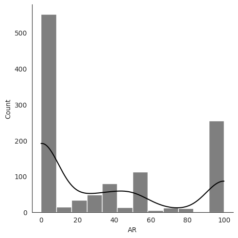

```python
sns.displot(data=output.select('AR').toPandas(), x='AR', kde=True, color ='#000000')
```

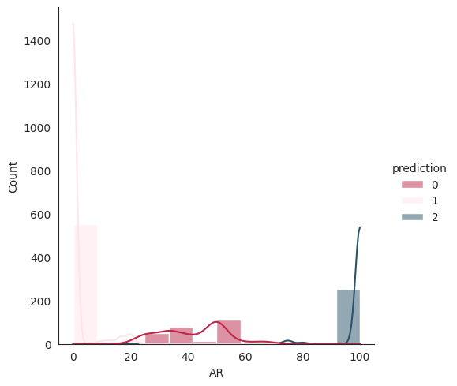

```python
sns.displot(data=output.select('AR', 'prediction').toPandas(), x='AR', kde=True, hue='prediction', palette =['#BB2649','#FFE4EA','#2B526B'])
```

## Hypothesis Testing On Conversion Rate

```python
df.createOrReplaceTempView("df")
```

```python
df.show()
```

```
+------+---------------+--------------+-----+------+--------+-----------+------+-----------+----------------+-------------------+------------------+--------------------+--------------------+--------------------+-----+
| ad_id|xyz_campaign_id|fb_campaign_id|  age|gender|interest|Impressions|Clicks|      Spent|Total_Conversion|Approved_Conversion|               CPC|                 CTR|                 TCR|                 ACR|   AR|
+------+---------------+--------------+-----+------+--------+-----------+------+-----------+----------------+-------------------+------------------+--------------------+--------------------+--------------------+-----+
|708746|            916|        103916|30-34|     M|      15|       7350|     1|1.429999948|               2|                  1|       1.429999948|0.013605442176870748|0.027210884353741496|0.013605442176870748| 50.0|
|708749|            916|        103917|30-34|     M|      16|      17861|     2|1.820000023|               2|                  0|      0.9100000115|0.011197581322434353|0.011197581322434353|                 0.0|  0.0|
|708771|            916|        103920|30-34|     M|      20|        693|     0|        0.0|               1|                  0|              10.0|                 0.0|  0.1443001443001443|                 0.0|  0.0|
|708815|            916|        103928|30-34|     M|      28|       4259|     1|       1.25|               1|                  0|              1.25|  0.0234796900680911|  0.0234796900680911|                 0.0|  0.0|
|708818|            916|        103928|30-34|     M|      28|       4133|     1|1.289999962|               1|                  1|       1.289999962|0.024195499637067505|0.024195499637067505|0.024195499637067505|100.0|
|708820|            916|        103929|30-34|     M|      29|       1915|     0|        0.0|               1|                  1|              10.0|                 0.0| 0.05221932114882506| 0.05221932114882506|100.0|
|708889|            916|        103940|30-34|     M|      15|      15615|     3|4.769999981|               1|                  0|1.5899999936666667| 0.01921229586935639|0.006404098623118796|                 0.0|  0.0|
|708895|            916|        103941|30-34|     M|      16|      10951|     1|1.269999981|               1|                  1|       1.269999981|0.009131586156515386|0.009131586156515386|0.009131586156515386|100.0|
|708953|            916|        103951|30-34|     M|      27|       2355|     1|        1.5|               1|                  0|               1.5| 0.04246284501061571| 0.04246284501061571|                 0.0|  0.0|
|708958|            916|        103952|30-34|     M|      28|       9502|     3|3.159999967|               1|                  0|1.0533333223333334| 0.03157230056830141|0.010524100189433803|                 0.0|  0.0|
|708979|            916|        103955|30-34|     M|      31|       1224|     0|        0.0|               1|                  0|              10.0|                 0.0| 0.08169934640522876|                 0.0|  0.0|
|709023|            916|        103962|30-34|     M|       7|        735|     0|        0.0|               1|                  0|              10.0|                 0.0|  0.1360544217687075|                 0.0|  0.0|
|709038|            916|        103965|30-34|     M|      16|       5117|     0|        0.0|               1|                  0|              10.0|                 0.0|0.019542700801250732|                 0.0|  0.0|
|709040|            916|        103965|30-34|     M|      16|       5120|     0|        0.0|               1|                  0|              10.0|                 0.0|          0.01953125|                 0.0|  0.0|
|709059|            916|        103968|30-34|     M|      20|      14669|     7|10.28000021|               1|                  1|1.4685714585714287|  0.0477196809598473|0.006817097279978185|0.006817097279978185|100.0|
|709105|            916|        103976|30-34|     M|      28|       1241|     0|        0.0|               1|                  1|              10.0|                 0.0| 0.08058017727639001| 0.08058017727639001|100.0|
|709115|            916|        103978|30-34|     M|      30|       2305|     1|0.569999993|               1|                  0|       0.569999993| 0.04338394793926247| 0.04338394793926247|                 0.0|  0.0|
|709124|            916|        103979|30-34|     M|      31|       1024|     0|        0.0|               1|                  1|              10.0|                 0.0|          0.09765625|          0.09765625|100.0|
|709179|            916|        103988|35-39|     M|      15|       4627|     1|1.690000057|               1|                  0|       1.690000057| 0.02161227577263886| 0.02161227577263886|                 0.0|  0.0|
|709183|            916|        103989|35-39|     M|      16|      21026|     4|4.630000114|               2|                  1|      1.1575000285|0.019024065442785124|0.009512032721392562|0.004756016360696281| 50.0|
+------+---------------+--------------+-----+------+--------+-----------+------+-----------+----------------+-------------------+------------------+--------------------+--------------------+--------------------+-----+
only showing top 20 rows
```

```python
spark.sql("SELECT xyz_campaign_id, avg(TCR), AVG(ACR) FROM df group by xyz_campaign_id ").show()
```

```
+---------------+--------------------+--------------------+
|xyz_campaign_id|            avg(TCR)|            avg(ACR)|
+---------------+--------------------+--------------------+
|            916|  0.0433434396446917|0.013687973603433455|
|            936| 0.05445478106855005|0.022755053485587855|
|           1178|0.002006955842373635|6.440969788276846E-4|
+---------------+--------------------+--------------------+
```

```python
def uni_eda(feat, ftype, scale=None, prob=False, agg='count', palette=None, font_scale=2):
  spark.sql("SELECT COUNT(DISTINCT {}) FROM df".format(feat)).show()
  spark.sql("SELECT DISTINCT {} FROM df".format(feat)).show()

  spark.sql("SELECT {0},count(*) \
            FROM df \
            GROUP BY {0}".format(feat)).show()

  spark.sql("SELECT {0}, {1}(TCR) TCR, \
            {1}(ACR) ACR \
            FROM df \
            GROUP BY {0}".format(feat, agg)).show()
  sns.set(font_scale = font_scale)
  sns.set_style('whitegrid')
  sns.barplot(
        x=feat,
        y='count',
        data=spark.sql("SELECT {0},count(*) count \
            FROM df \
            GROUP BY {0}".format(feat)).toPandas(),
        palette=palette
    )
  plt.savefig("{}_uni.png".format(feat))

  # sns.set(font_scale = 2)
  fig, axes=plt.subplots(nrows=1, ncols=2, figsize=(50,10))
  i=0
  for col in ['TCR', 'ACR']:
    sns.set_style('whitegrid')
    sns.barplot(
        x=feat,
        y=col,
        data=spark.sql("SELECT {0}, {1}(TCR) TCR, \
                {1}(ACR) ACR \
                FROM df \
                GROUP BY {0}".format(feat, agg)).toPandas(),
                palette=palette,
        ax=axes[i]
    )
    if scale:
      axes[i].set_yscale(scale)
    # axes[i].set_ylabel(col, fontsize=40)
    # axes[i].set_xlabel(feat, fontsize=40)
    # axes[i].set_yticklabels(fontsize=40)
    # axes[i].set_xticklabels(fontsize=40)
    i += 1
  sns.despine()
  plt.savefig("{}_conversion_rate.png".format(feat))
```

```
+-------------------+
|count(DISTINCT age)|
+-------------------+
|                  4|
+-------------------+

+-----+
|  age|
+-----+
|30-34|
|35-39|
|45-49|
|40-44|
+-----+

+-----+--------+
|  age|count(1)|
+-----+--------+
|30-34|     426|
|35-39|     248|
|45-49|     259|
|40-44|     210|
+-----+--------+

+-----+--------------------+--------------------+
|  age|                 TCR|                 ACR|
+-----+--------------------+--------------------+
|30-34|0.033813702086295104|0.015259430915005513|
|35-39|0.019070433977986495|0.005322400012964302|
|45-49| 0.02016066806325136|0.005806946428783446|
|40-44|0.021458065782950664|0.011312305264776527|
+-----+--------------------+--------------------+
```

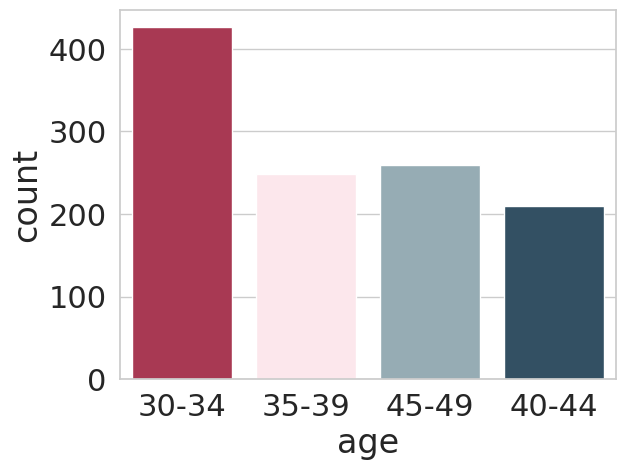

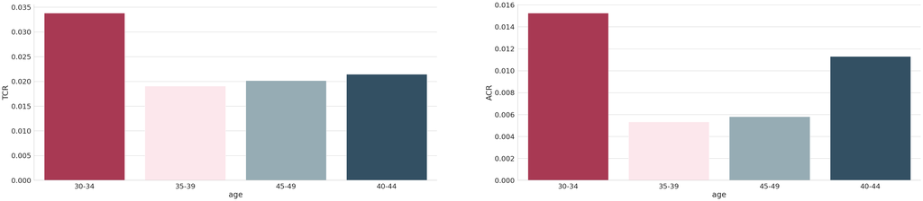

```python
uni_eda("age", "cat", agg='AVG', palette=['#BB2649','#FFE4EA', '#91AEB9' ,'#2B526B'])
```

```python
from pyspark.sql.functions import mean, variance, count
from scipy.stats import t
from math import sqrt
from pyspark.sql.functions import mean, variance
from math import sqrt

def one_sided_test(df, feat, vals, test_col, sample_rate=0.2):
  samples_1 = spark.sql("SELECT {0}, * FROM df WHERE {0} = '{1}'".format(feat, vals[0]))
  samples_2 = spark.sql("SELECT {0}, * FROM df WHERE {0} = '{1}'".format(feat, vals[1]))

  mean_1, var_1, count_1 = tuple(samples_1.select(mean(test_col), variance(test_col), count(test_col)).collect()[0])
  mean_2, var_2, count_2 = tuple(samples_2.select(mean(test_col), variance(test_col), count(test_col)).collect()[0])

  numerator = mean_1 - mean_2
  denominator = sqrt((var_1 / count_1) + (var_2 / count_2))
  t_test_statistic = numerator / denominator

  degrees_of_freedom = count_1 + count_2 - 2
  p_value = 1- t.cdf(t_test_statistic, df = degrees_of_freedom)

  print("Probability that the two have the same distribution:", p_value > 0.05)
  return p_value
```

```python
one_sided_test(df, 'age', ['30-34', '35-39'], 'TCR')
```

```
Probability that the two have the same distribution: False
```

```
0.0013050879152307626
```

```python
one_sided_test(df, 'age', ['30-34', '45-49'], 'TCR')
```

```
Probability that the two have the same distribution: False
```

```
0.004738328335160524
```

```python
one_sided_test(df, 'age', ['30-34', '40-44'], 'TCR')
```

```
Probability that the two have the same distribution: False
```

```
0.04428330676481895
```

```python
one_sided_test(df, 'age', ['30-34', '35-39'], 'ACR')
one_sided_test(df, 'age', ['30-34', '45-49'], 'ACR')
one_sided_test(df, 'age', ['30-34', '40-44'], 'TCR')
```

```
Probability that the two have the same distribution: False
Probability that the two have the same distribution: False
Probability that the two have the same distribution: False
```

```
0.04428330676481895
```